# GC analysis - CssS set on acidic (pH5) LB

Kenyon

December 22, 2015

#### CssS-7 strain set grown on LB adjusted to pH5 for 20 hours; 7 replicates grown

Regenerated CssS strain set grown on LB acidified to pH5 with HCl

**Description of Strains:**

Strain set consists of single-gene deletion strains:

- AM373: Reference strain; no deletions
- [cssS:](http://subtiwiki.uni-goettingen.de/bank/index.php?gene=cssS&action=Go) two-component sensor kinase gene that response to secretion stress deleted
- [mcpA:](http://subtiwiki.uni-goettingen.de/bank/index.php?gene=mcpA&action=Go) membrane-bound chemotaxis receptor gene deleted
- [nhaK:](http://subtiwiki.uni-goettingen.de/bank/index.php?gene=nhaK&action=Go) cation/H+ antiporter gene deleted

Double-gene deletion strains:

- CM : cssS/mcpA double KO strain
- CN : cssS/nhaK KO
- MN : mcpA/nhaK KO

#### Step 1 - Import files

Printout of all .csv files containing the relevant growth curve data:

```
## [1] "2016-01-28-ACMN-20hrs-LB-HCl-1.csv"
## [2] "2016-01-29-ACMN-20hrs-LB-HCl-2.csv"
## [3] "2016-02-01-ACMN-20hrs-LB-HCl-3.csv"
## [4] "2016-02-02-ACMN-20hrs-LB-HCl-4.csv"
## [5] "2016-02-03-ACMN-20hrs-LB-HCl-5.csv"
## [6] "2016-02-08-ACMN-20hrs-LB-HCl-7.csv"
## [7] "2016-02-09-ACMN-20hrs-LB-HCl-6.csv"
```

Step 1.b - Merge individual ‘.csv’ files into one

#### Step 2: Correct for plate reader OD saturation

#### Step 3: Preliminary run of data to check for correct feature identification

observations: All plots appear fitted correctly

#### Step 4: Apply version of ‘gcfall’ that merges ln=TRUE and ln=FALSE datasets

### Growth Curve Plots:

(dashed line is ploted on each curve to highlight the position and slope of the identified max GR)

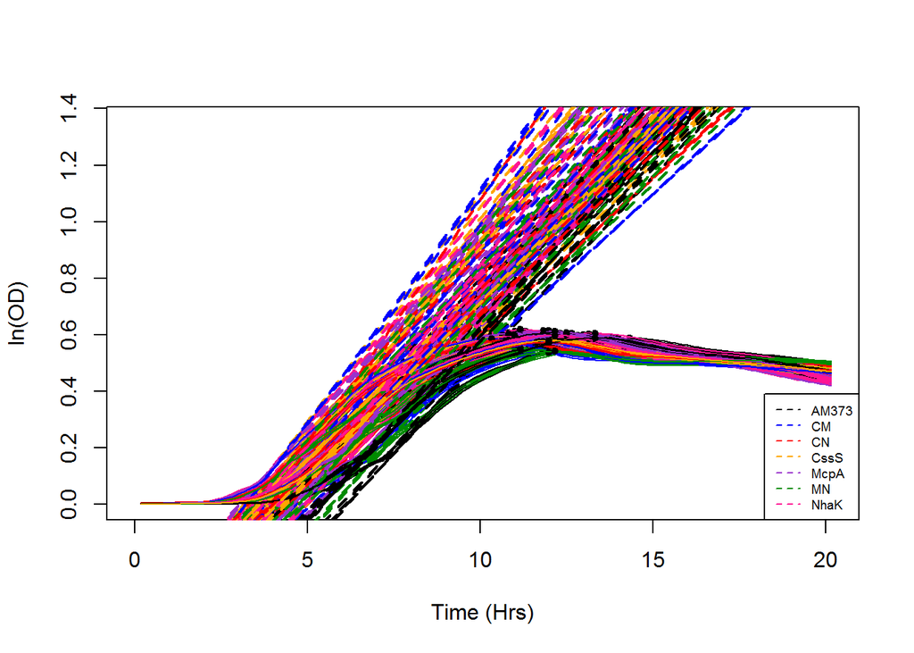

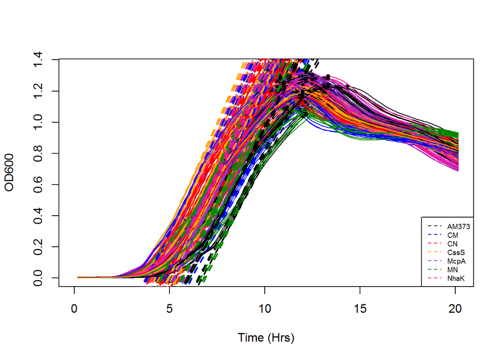

Plots of each mutant strains (color) relative to AM373 (grey):  
- there is one plot per well grown in these images, so 7 experiments x #technical replicates/experiments

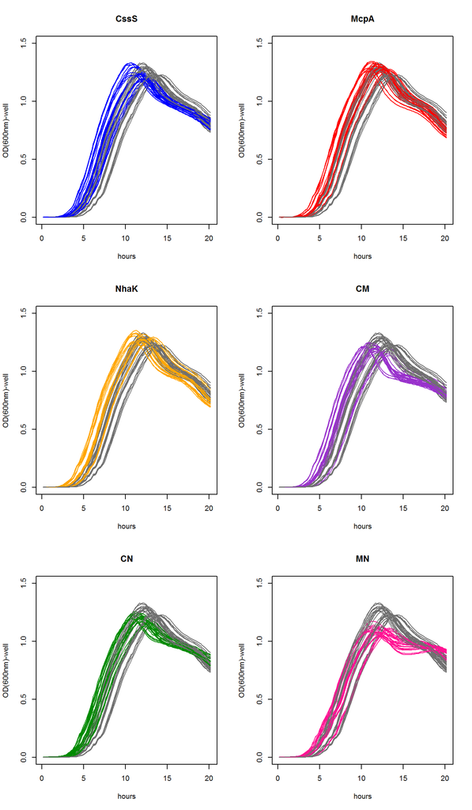

#### Step 5: save data and combine technical replicates:

Each experiment had 2-4 technical replicates in which the same strain was grown in multiple wells; this function calculates the average value of each feature found among the technical replicates.

```r
write.csv(gcdat2,paste0(folder_name,media,"-gcfit-",today,".csv"))

# Combine technical replicates
source('~/Bacillus_subtilis/Growth Rates/growth-curves-ryan/LM_controls-Sept2015/average_triples_ingcobj.R')

gcavg<-avg_triples(gcdat2,"DEF")

#write.csv(gcavg,paste0(folder_name,media,"-gcfit-repsavgd",today,".csv"))
```

### Plots of GR paramaters by strain

- ln_mu.spline : max growth rate of ln-transformed data (doublings/hr)
- mu.spline: max growth rate, raw data (delta-OD/hr)
- lambda.spline: lag time (hrs)
- A.spline: MaxOD of growth curve (OD)
- integral.spline: integrated area under each growth curve

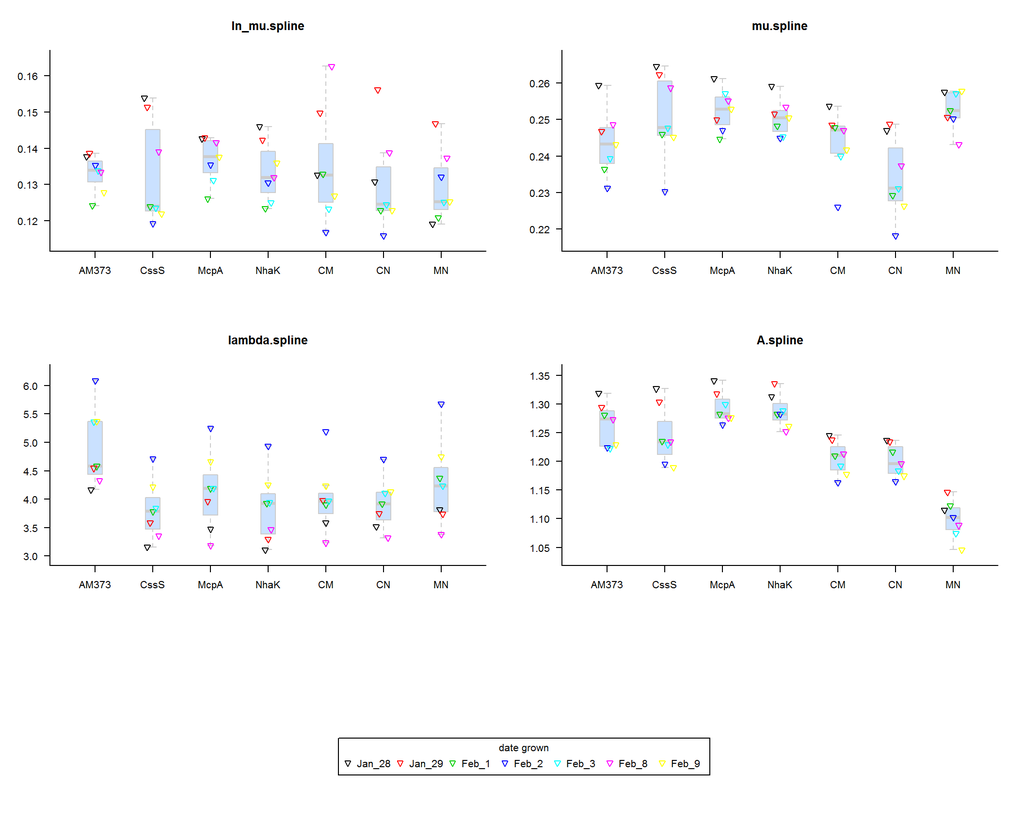

## Tables of GR parameters

avg: average of all replicates  
sd: sd across replicates  
pval: results of paired t-test against AM373 reference strain values (no Mult Comp correction)  
sig: if <0.05, marked with “*"  
%AM373: percent differenc from AM373

|  | AM373 | CssS | McpA | NhaK | CM | CN | MN |
| --- | --- | --- | --- | --- | --- | --- | --- |
| ln_mu avg | 0.133 | 0.133 | 0.137 | 0.134 | 0.135 | 0.13 | 0.129 |
| ln_mu sd | 0.00524 | 0.0147 | 0.00637 | 0.00842 | 0.016 | 0.0135 | 0.00988 |
| ln_mu pval | NaN | 0.951 | 0.0623 | 0.825 | 0.748 | 0.562 | 0.325 |
| ln_mu sig | NA |  |  |  |  |  |  |
| ln_mu %AM373 | 0 | 0.00218 | 0.0286 | 0.00426 | 0.0151 | -0.0205 | -0.0263 |

|  | AM373 | CssS | McpA | NhaK | CM | CN | MN |
| --- | --- | --- | --- | --- | --- | --- | --- |
| mu avg | 0.244 | 0.251 | 0.253 | 0.25 | 0.244 | 0.234 | 0.253 |
| mu sd | 0.00923 | 0.0121 | 0.0058 | 0.00497 | 0.00897 | 0.0111 | 0.00534 |
| mu pval | NaN | 0.0141 | 0.00756 | 0.00841 | 0.981 | 0.0054 | 0.0542 |
| mu sig | NA | * | * | * |  | * |  |
| mu %AM373 | 0 | 0.0293 | 0.037 | 0.0282 | -0.000223 | -0.0395 | 0.0375 |

|  | AM373 | CssS | McpA | NhaK | CM | CN | MN |
| --- | --- | --- | --- | --- | --- | --- | --- |
| lambda avg | 4.92 | 3.81 | 4.13 | 3.85 | 4.01 | 3.92 | 4.28 |
| lambda sd | 0.699 | 0.527 | 0.695 | 0.626 | 0.612 | 0.455 | 0.762 |
| lambda pval | NaN | 2.55e-05 | 0.000329 | 2.96e-05 | 0.000264 | 0.000126 | 0.00236 |
| lambda sig | NA | * | * | * | * | * | * |
| lambda %AM373 | 0 | -0.226 | -0.16 | -0.218 | -0.184 | -0.203 | -0.13 |

|  | AM373 | CssS | McpA | NhaK | CM | CN | MN |
| --- | --- | --- | --- | --- | --- | --- | --- |
| A avg | 1.26 | 1.24 | 1.29 | 1.29 | 1.21 | 1.2 | 1.1 |
| A sd | 0.0384 | 0.0519 | 0.0274 | 0.0287 | 0.0301 | 0.0287 | 0.0333 |
| A pval | NaN | 0.101 | 0.0231 | 0.101 | 3.88e-05 | 2.63e-05 | 4.57e-06 |
| A sig | NA |  | * |  | * | * | * |
| A %AM373 | 0 | -0.0146 | 0.0241 | 0.0195 | -0.0456 | -0.0494 | -0.13 |

**lambda.spline:**

**ln_mu.spline:**

Looks interesting, but unfortunately, none of the variation is stat sig

**A.spline:**

All 3 double-mutants have sig lower maxOD than AM373 (and McpA, NhaK, and CssS) MN is sig lower than all strains

### Tukey HSD analysis

Identify pairs of strains that are significantly different from each other in each growth feature

Only pairs that are significantly different (p<0.05):

```
##                      meas    strains    difs perc_dif    pvals p05
## CssS-AM3731 lambda.spline CssS-AM373 -1.1100  -0.2260 8.98e-12   *
## McpA-AM3731 lambda.spline McpA-AM373 -0.7900  -0.1600 5.85e-08   *
## NhaK-AM3731 lambda.spline NhaK-AM373 -1.0700  -0.2820 2.44e-11   *
## CM-AM3731   lambda.spline   CM-AM373 -0.9070  -0.1840 2.09e-09   *
## CN-AM3731   lambda.spline   CN-AM373 -1.0000  -0.2030 1.68e-10   *
## MN-AM3731   lambda.spline   MN-AM373 -0.6410  -0.1680 4.79e-06   *
## McpA-CssS1  lambda.spline  McpA-CssS  0.3230   0.0656 4.18e-02   *
## MN-CssS1    lambda.spline    MN-CssS  0.4720   0.0958 7.53e-04   *
## MN-NhaK1    lambda.spline    MN-NhaK  0.4330   0.1140 2.30e-03   *
## MN-CN1      lambda.spline      MN-CN  0.3590   0.0943 1.70e-02   *
## McpA-AM3732      A.spline McpA-AM373  0.0304   0.0241 4.16e-02   *
## CM-AM3732        A.spline   CM-AM373 -0.0576  -0.0456 1.14e-05   *
## CN-AM3732        A.spline   CN-AM373 -0.0624  -0.0494 2.46e-06   *
## MN-AM3732        A.spline   MN-AM373 -0.1640  -0.1320 0.00e+00   *
## McpA-CssS2       A.spline  McpA-CssS  0.0489   0.0387 1.84e-04   *
## NhaK-CssS2       A.spline  NhaK-CssS  0.0431   0.0341 1.14e-03   *
## CM-CssS2         A.spline    CM-CssS -0.0392  -0.0315 3.71e-03   *
## CN-CssS2         A.spline    CN-CssS -0.0440  -0.0348 8.68e-04   *
## MN-CssS2         A.spline    MN-CssS -0.1450  -0.1150 0.00e+00   *
## CM-McpA2         A.spline    CM-McpA -0.0881  -0.0697 9.65e-10   *
## CN-McpA2         A.spline    CN-McpA -0.0929  -0.0735 2.43e-10   *
## MN-McpA2         A.spline    MN-McpA -0.1940  -0.1560 0.00e+00   *
## CM-NhaK2         A.spline    CM-NhaK -0.0822  -0.0651 5.39e-09   *
## CN-NhaK2         A.spline    CN-NhaK -0.0870  -0.0689 1.31e-09   *
## MN-NhaK2         A.spline    MN-NhaK -0.1880  -0.1510 0.00e+00   *
## MN-CM2           A.spline      MN-CM -0.1060  -0.0841 5.95e-12   *
## MN-CN2           A.spline      MN-CN -0.1020  -0.0815 2.21e-11   *
```

All pairs:

```r
print(tuk_dat)
```

```
##                      meas    strains      difs perc_dif    pvals p05
## CssS-AM373   ln_mu.spline CssS-AM373  0.000290  0.00218 1.00e+00
## McpA-AM373   ln_mu.spline McpA-AM373  0.003800  0.02860 9.70e-01
## NhaK-AM373   ln_mu.spline NhaK-AM373  0.000566  0.00425 1.00e+00
## CM-AM373     ln_mu.spline   CM-AM373  0.002010  0.01510 9.99e-01
## CN-AM373     ln_mu.spline   CN-AM373 -0.002720 -0.02050 9.95e-01
## MN-AM373     ln_mu.spline   MN-AM373 -0.003500 -0.02620 9.80e-01
## McpA-CssS    ln_mu.spline  McpA-CssS  0.003510  0.02640 9.80e-01
## NhaK-CssS    ln_mu.spline  NhaK-CssS  0.000276  0.00207 1.00e+00
## CM-CssS      ln_mu.spline    CM-CssS  0.001720  0.01290 1.00e+00
## CN-CssS      ln_mu.spline    CN-CssS -0.003010 -0.02260 9.91e-01
## MN-CssS      ln_mu.spline    MN-CssS -0.003790 -0.02850 9.71e-01
## NhaK-McpA    ln_mu.spline  NhaK-McpA -0.003230 -0.02430 9.87e-01
## CM-McpA      ln_mu.spline    CM-McpA -0.001790 -0.01340 9.99e-01
## CN-McpA      ln_mu.spline    CN-McpA -0.006520 -0.04900 7.17e-01
## MN-McpA      ln_mu.spline    MN-McpA -0.007300 -0.05480 6.02e-01
## CM-NhaK      ln_mu.spline    CM-NhaK  0.001450  0.01090 1.00e+00
## CN-NhaK      ln_mu.spline    CN-NhaK -0.003290 -0.02470 9.86e-01
## MN-NhaK      ln_mu.spline    MN-NhaK -0.004060 -0.03050 9.59e-01
## CN-CM        ln_mu.spline      CN-CM -0.004730 -0.03560 9.17e-01
## MN-CM        ln_mu.spline      MN-CM -0.005510 -0.04140 8.45e-01
## MN-CN        ln_mu.spline      MN-CN -0.000778 -0.00583 1.00e+00
## CssS-AM3731 lambda.spline CssS-AM373 -1.110000 -0.22600 8.98e-12   *
## McpA-AM3731 lambda.spline McpA-AM373 -0.790000 -0.16000 5.85e-08   *
## NhaK-AM3731 lambda.spline NhaK-AM373 -1.070000 -0.28200 2.44e-11   *
## CM-AM3731   lambda.spline   CM-AM373 -0.907000 -0.18400 2.09e-09   *
## CN-AM3731   lambda.spline   CN-AM373 -1.000000 -0.20300 1.68e-10   *
## MN-AM3731   lambda.spline   MN-AM373 -0.641000 -0.16800 4.79e-06   *
## McpA-CssS1  lambda.spline  McpA-CssS  0.323000  0.06560 4.18e-02   *
## NhaK-CssS1  lambda.spline  NhaK-CssS  0.038800  0.00788 1.00e+00
## CM-CssS1    lambda.spline    CM-CssS  0.205000  0.05390 4.12e-01
## CN-CssS1    lambda.spline    CN-CssS  0.112000  0.02290 9.20e-01
## MN-CssS1    lambda.spline    MN-CssS  0.472000  0.09580 7.53e-04   *
## NhaK-McpA1  lambda.spline  NhaK-McpA -0.284000 -0.07460 1.01e-01
## CM-McpA1    lambda.spline    CM-McpA -0.117000 -0.02390 9.04e-01
## CN-McpA1    lambda.spline    CN-McpA -0.210000 -0.04280 3.84e-01
## MN-McpA1    lambda.spline    MN-McpA  0.149000  0.03900 7.59e-01
## CM-NhaK1    lambda.spline    CM-NhaK  0.167000  0.03390 6.52e-01
## CN-NhaK1    lambda.spline    CN-NhaK  0.073700  0.01500 9.90e-01
## MN-NhaK1    lambda.spline    MN-NhaK  0.433000  0.11400 2.30e-03   *
```

[output cut: 9 more lines]

```
## McpA-CssS2       A.spline  McpA-CssS  0.048900  0.03870 1.84e-04   *
## NhaK-CssS2       A.spline  NhaK-CssS  0.043100  0.03410 1.14e-03   *
## CM-CssS2         A.spline    CM-CssS -0.039200 -0.03150 3.71e-03   *
## CN-CssS2         A.spline    CN-CssS -0.044000 -0.03480 8.68e-04   *
## MN-CssS2         A.spline    MN-CssS -0.145000 -0.11500 0.00e+00   *
## NhaK-McpA2       A.spline  NhaK-McpA -0.005840 -0.00469 9.96e-01
## CM-McpA2         A.spline    CM-McpA -0.088100 -0.06970 9.65e-10   *
## CN-McpA2         A.spline    CN-McpA -0.092900 -0.07350 2.43e-10   *
## MN-McpA2         A.spline    MN-McpA -0.194000 -0.15600 0.00e+00   *
## CM-NhaK2         A.spline    CM-NhaK -0.082200 -0.06510 5.39e-09   *
## CN-NhaK2         A.spline    CN-NhaK -0.087000 -0.06890 1.31e-09   *
## MN-NhaK2         A.spline    MN-NhaK -0.188000 -0.15100 0.00e+00   *
## CN-CM2           A.spline      CN-CM -0.004800 -0.00380 9.99e-01
## MN-CM2           A.spline      MN-CM -0.106000 -0.08410 5.95e-12   *
## MN-CN2           A.spline      MN-CN -0.102000 -0.08150 2.21e-11   *
```